# K579: Homework 1

Team 7: usethia,limdad

### Download “breast_cancer.csv” data file from Canvas. Make sure you read the description of Question 6 (in HW1 file) carefully before working on this part.

### Import the data into R as “cancer”

```r
cancer <- read.csv("breast_cancer.csv")
```

### After you import the data, we need to convert “Class” variable into a factor, so that R treats it as a categorical variable, instead of a numeric variable. Run the following line of code

```r
cancer$Class <- as.factor(cancer$Class)
```

### 1. Split the dataset into 80% training and 20% testing

```r
library(caret)
set.seed(23)

# Randomly pick the rows for training partition
train_rows = createDataPartition(y = cancer$Class,
                                 p = 0.80, list = FALSE)

cancer_train = cancer[train_rows,]
cancer_test = cancer[-train_rows,] # "-" means selecting rows *not* included in train_rows
```

### 2. Build a decision tree model

```r
library(rpart)

tree <- rpart(Class ~ ., data = cancer_train,
             method = "class",
             parms = list(split = "information"))
             control = list(minsplit = 5, maxdepth = 3, cp =0)
```

#The model is stored in the tree object

### 3. Plot the tree, and then answer the following questions:

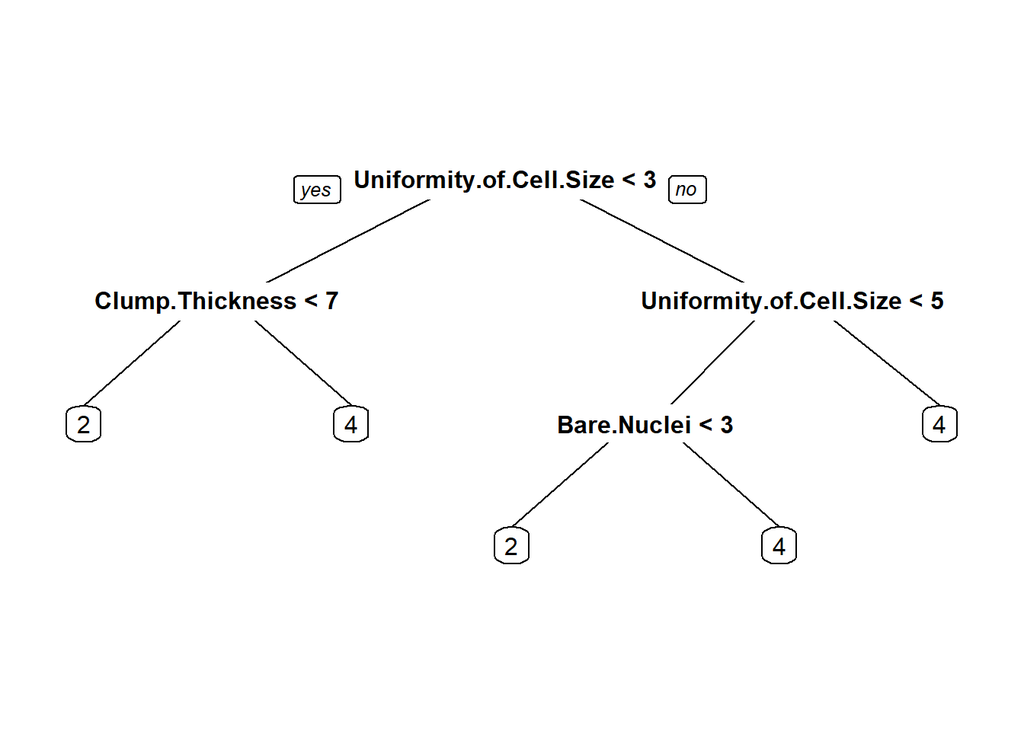

```
- 3.1. How many decision nodes are there in your tree?
## There are 4 decision nodes
- 3.2. Pick one decision rule from your tree and interpret it
## If the clump thickness is <7: then cancer is benign else it is malignant
```

```r
set.seed(1)
library(rpart.plot)
prp(tree, varlen = 0)
```

## Making predictions

```r
pred_tree = predict(tree, cancer_test, type = "class")
```

### 4. Evaluate the performance of your tree. Specifically, report the following metrics: (1) confusion matrix; (2) accuracy; (3) precision, recall, f-measure for “malignant” class; (4) AUC for “malignant” class

```r
confusionMatrix(pred_tree, as.factor(cancer_test[,10]), positive= "4")
```

```
## Confusion Matrix and Statistics
##
##           Reference
## Prediction  2  4
##          2 83  5
##          4  5 42
##
##                Accuracy : 0.9259
##                  95% CI : (0.868, 0.9639)
##     No Information Rate : 0.6519
##     P-Value [Acc > NIR] : 7.08e-14
##
##                   Kappa : 0.8368
##
##  Mcnemar's Test P-Value : 1
##
##             Sensitivity : 0.8936
##             Specificity : 0.9432
##          Pos Pred Value : 0.8936
##          Neg Pred Value : 0.9432
##              Prevalence : 0.3481
##          Detection Rate : 0.3111
##    Detection Prevalence : 0.3481
##       Balanced Accuracy : 0.9184
##
##        'Positive' Class : 4
##
```

```r
tree
```

```
## n= 548
##
## node), split, n, loss, yval, (yprob)
##       * denotes terminal node
##
##  1) root 548 192 2 (0.649635036 0.350364964)
##    2) Uniformity.of.Cell.Size< 2.5 338   9 2 (0.973372781 0.026627219)
##      4) Clump.Thickness< 6.5 329   2 2 (0.993920973 0.006079027) *
##      5) Clump.Thickness>=6.5 9   2 4 (0.222222222 0.777777778) *
##    3) Uniformity.of.Cell.Size>=2.5 210  27 4 (0.128571429 0.871428571)
##      6) Uniformity.of.Cell.Size< 4.5 69  25 4 (0.362318841 0.637681159)
##       12) Bare.Nuclei< 2.5 22   3 2 (0.863636364 0.136363636) *
##       13) Bare.Nuclei>=2.5 47   6 4 (0.127659574 0.872340426) *
##      7) Uniformity.of.Cell.Size>=4.5 141   2 4 (0.014184397 0.985815603) *
```

```r
tree$byClass["F1"]
```

[output not shown]

- The Accuracy is 0.9259, which indicates that the model will predict accurate results 92.59% of the times and has an error rate of 7.41%.
- The precision of malignant is PPV = 0.8936= 89.36%
- Recall for malignant is Sensitivity= 0.8936= 89.36%
- F Value is 0.893617 = 89.3617%
- We can use the probabilities and `roc()` function from pROC package to get the performance

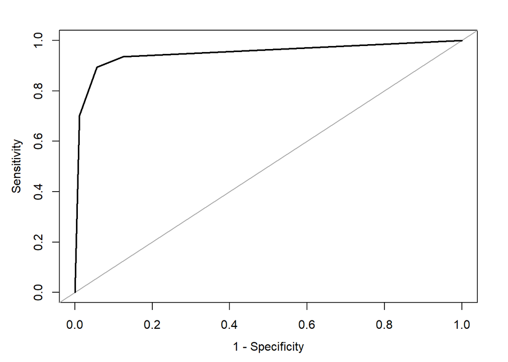

```r
library(dplyr)

# get classification probabilities
pred_tree_prob <- predict(tree, cancer_test, prob = T)

# append the prob of Survived = 1 to the validation/testing set
cancer_test_roc <- cancer_test %>%
  mutate(prob = pred_tree_prob[,2]) %>%
  arrange(desc(prob))

library(pROC)

# roc function requires the actual values and the probabilities
roc_tree <- roc(response = cancer_test_roc$Class,
                predictor = cancer_test_roc$prob)

plot(roc_tree, legacy.axes = T, asp = NA)
```

```r
# get AUC
auc(roc_tree)
```

```
## Area under the curve: 0.9497
```

- AUC is 0.9497= 94.97%

### 5. Now, let’s consider using K-NN to do the classification. Is there any need to normalize the data? Why or why not? If you think normalization is needed, write your code below to do so. Feel free to re-use code from the in-class exercise. If you think normalization is not necessary, explain why and you do not need to write any code.

```r
#As the range for all the variables fall within 1-10, normalization is not necessary. We only need to normalize data when there is a major difference between the values.
```

### 6. Build a K-NN model with your own choice of k value, and evaluate the performance of your K-NN model just as in 4. Does it have a higher or lower AUC than your decision tree model?

```r
library(class)

pred_knn = knn(train = cancer_train[,1:9],
               test = cancer_test[,1:9],
               cl = cancer_train[,10],
               k = 3)

length(pred_knn)
```

```
## [1] 135
```

```r
cm <- confusionMatrix(pred_knn, factor(cancer_test[,10]), positive = "4")
cm
```

```
## Confusion Matrix and Statistics
##
##           Reference
## Prediction  2  4
##          2 83  1
##          4  5 46
##
##                Accuracy : 0.9556
##                  95% CI : (0.9058, 0.9835)
##     No Information Rate : 0.6519
##     P-Value [Acc > NIR] : <2e-16
##
##                   Kappa : 0.904
##
##  Mcnemar's Test P-Value : 0.2207
##
##             Sensitivity : 0.9787
##             Specificity : 0.9432
##          Pos Pred Value : 0.9020
##          Neg Pred Value : 0.9881
##              Prevalence : 0.3481
##          Detection Rate : 0.3407
##    Detection Prevalence : 0.3778
##       Balanced Accuracy : 0.9610
##
##        'Positive' Class : 4
##
```

```r
cm$byClass["F1"]
```

```
##        F1
## 0.9387755
```

```r
knn_model = knn3(Class~.,data = cancer_train, k=3)
pred_knn3 = predict(knn_model, cancer_test, type="prob")
roc_knn = roc(response = ifelse(cancer_test$Class == "4", 1, 0),
predictor = pred_knn3[,2])
auc(roc_knn)
```

```
## Area under the curve: 0.9707
```

- The AUC for KNN model is 0.9707 as opposed to the UC for our decision tree model, which was 0.9497. The AUC for KNN> AUC for decision tree.

### 7. Try several different k values (at least 4), report the AUC of each one you tried. Also, report which k value gives you the highest AUC. Try using a for loop for this task.

```r
ab = c()

#using the same training and testing data
for (i in c(2,4,6,5)) {
    knn_models = knn3(Class~., data=cancer_train, k=i)
    pred_knns = predict(knn_models, cancer_test, type="prob")
    roc_knns = roc(response = ifelse(cancer_test$Class == "4", 1, 0),
    predictor = pred_knns[,2])
    ab= c(ab, auc(roc_knns))
}
print(ab)
```

```
## [1] 0.9711074 0.9769101 0.9825919 0.9827128
```

### 8. Build a naive bayes model, and evaluate its performance on the same testing data. Does it have higher or lower AUC than your best decision tree and k-NN models?

```r
library(e1071)
library(funModeling)

nb_model <- naiveBayes(Class ~ . , data = cancer_train)
```

```r
pred_nb <- predict(nb_model, cancer_test)

# we can also obtain class probability predictions
pred_nb_prob <- predict(nb_model, cancer_test, type= "raw")
```

```r
cm <- confusionMatrix(pred_nb, as.factor(cancer_test$Class), mode = "prec_recall", positive="4")
cm
```

```
## Confusion Matrix and Statistics
##
##           Reference
## Prediction  2  4
##          2 83  1
##          4  5 46
##
##                Accuracy : 0.9556
##                  95% CI : (0.9058, 0.9835)
##     No Information Rate : 0.6519
##     P-Value [Acc > NIR] : <2e-16
##
##                   Kappa : 0.904
##
##  Mcnemar's Test P-Value : 0.2207
##
##               Precision : 0.9020
##                  Recall : 0.9787
##                      F1 : 0.9388
##              Prevalence : 0.3481
##          Detection Rate : 0.3407
##    Detection Prevalence : 0.3778
##       Balanced Accuracy : 0.9610
##
##        'Positive' Class : 4
##
```

- Gives accuracy of 0.9556, which implies that the model will be accurate 95.56% of the times.

## Make ROC Curve for Class “Malignant”

```r
library(dplyr)

cancer_test_roc <- cancer_test %>%
  mutate(prob = pred_nb_prob[,2]) %>%
  arrange(desc(prob)) %>%
  mutate(malignant = ifelse(Class == "4", 1, 0))
```

- The `pROC` package provides useful functions to make ROC plots and calculate AUC

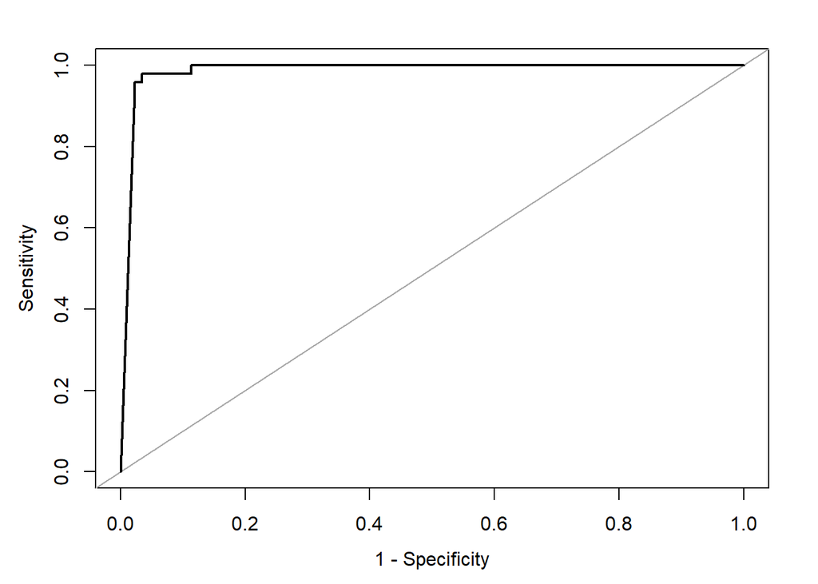

```r
library(pROC)
roc_nb <- roc(response = cancer_test_roc$malignant,
              predictor = cancer_test_roc$prob)

plot(roc_nb, legacy.axes = T, asp = NA)
```